# Your Digest for Tuesday, Aug 29, 2023 11:59 PM

> [!INFO] Renin and aldosterone are increased in #pregnancy  
> Pregnancy specific ranges are required for evaluation  
> Spironolactone - used to treat Conn's syndrome - is contraindicated in pregnancy because as an *antiandrogen* it can cause feminization of a male foetus.

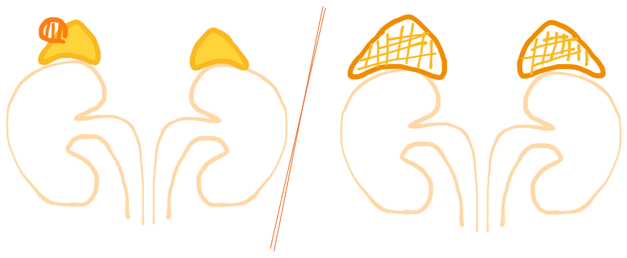

Conn syndrome was named after J. W. **Conn who first described it in 1955, in a patient who had hypertension with an aldosterone-producing adenoma**.  
Classic Conn's syndrome = adrenal adenoma.  
The adenoma is characterized by

- increased aldosterone secretion from the adrenal glands,
- suppressed plasma renin,
- hypertension,
- and hypokalemia.

**Bilateral adrenal hyperplasia** is actually a much commoner cause of hyperaldosteronism than Conn's syndrome.

##### Diagnosis of Conn's syndrome

Elevated ARR (aldosterone renin ratio) is a screening test:

- Some people who have elevated ARR will suppress aldosterone appropriately when given a saline load *excluding a diagnosis of Conn's*.
- ACE inhibitors can raise renin and lower aldosterone levels, thereby causing **false-negative ARR results**; [Source](https://www.ncbi.nlm.nih.gov/books/NBK459197/)
- **Confirmatory test:** Inadequate suppression of aldosterone following infusion of 2L of N/S over 4 hours.

> Is thought to be caused by abrupt downward bulging (snapping) of the anterior leaflet as left ventricular pressure drops below left atrial pressure during diastole.  
> [Source](https://www.msdmanuals.com/professional/multimedia/audio/mitral_valve_opening_snap)

> [!NOTE] What is the relationship between Calcium and Phosphate?

> To illustrate this further:  
> "The ensuing hyperphosphatemia may induce potentially symptomatic hypocalcemia due to calcium-phosphate precipitation in the tissues." - [Source: Hyperphosphatemia](https://www.ncbi.nlm.nih.gov/books/NBK551586/)

> **Thyroid peroxidase** – TPO catalyzes the iodination of tyrosine residues of Tg to form monoiodotyrosine and diiodotyrosine. Nearly all patients with **Hashimoto's thyroiditis** have high serum concentrations of TPO antibodies.

#### Graves' disease

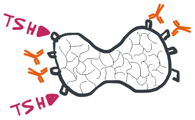

- Common cause of hyperthyroidism
- Commoner in **women - 30 - 60** years.
- TSH-Receptor antibodies (thyrotropin receptor or TRAb) stimulate thyroid gland to make thyroid hormones. -> *diffuse, **non tender**, goiter*
- Graves *eye disease* is a prominent feature.
- Disease follows a *relapsing* remitting course. Majority have *recurrences*.
- Associated with other autoimmune diseases like *myasthenia, vitiligo, pernicious anaemia*
- Patients will usually *eventually* become *hypothyroid*.
- *Orbitopathy* and *pretibial myxoedema* are not related to thyroxine levels.

> [!TIP] Mnemonic  
> De quer*vain* - *pain*ful  
> Hasimotos's - chronic

[figure not shown]

> Grand Seikos are japanese watches -> chronic ;)

##### De quervrain (subacute thyroiditis)

Fundamentaly, a clinical diagnosis.  
Neck pain + thyroid tenderness + diffuse goiter usually = subacute thyroiditis.

fibrous thyroiditis (Reidel's thyroiditis) -> fibrosis of the thyroid gland; woody, hard gland on palpation. Thyroid parenchyma becomes slowly replaced with dense fibroid tissue.  
Presentation: Dyspnoea, Dysphagia, hoarseness due to involvement of extrathyroidal structure by the fibrosis.

```
2. Ectopic ACTH producing tumours have *absolutely no inhibition* from glucocorticoids. (with the exception of some pulmonar neuroendocrine tumours)
```

#TODO ? aren't these rate control drugs? AFFIRM trial?

```
2. Ophthalmoplegia, ataxia, and areflexia
```

#2022SBR-MAY Q11  
Secondary causes of TTP are:  
?Pregnancy, OCP, SLE, infection and drugs (like clopidogrel)

# Management of TTP and HUS

> [!INFO] Pack-years and COPD
> $$
> PackYears = PacksPerDay \times YearsSmoked
> $$
> Pack years > 20 => risk factor for COPD. [Source](https://www.elsevier.es/en-revista-revista-medica-del-hospital-general-325-articulo-risk-factors-for-chronic-obstructive-S0185106315000554)

## Chronic bronchitis and Emphysema

#2022SBR-MAY Q26

COPD is an overlap between chronic bronchitis and emphysema.  
Severe COPD may progress more towards one or the other of these phenotypes.

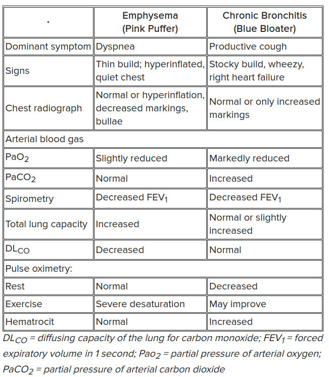

> [!TIP] Blue bloaters are more predisposed to pulmonary hypertension and cor pulmonale.
> - Pink puffers tend to have better oxygenation and so secondary polycythemia doesn't develop.
> - In blue bloaters, saturation may actually increase with exercise but in pink puffers, there is marked desaturation with exercise.

Enthesitis causing plantar fascitis or achilles **tendon enthesitis** can occur.

# Numerical Sex chromosome abnormalities

#2022SBR-MAY Q18

- impaired sexual function (decreased drive, erectile dysfunction)  
  No tall stature, gynaecomastia like Klinefelter syndrome.

# Meningitis and Encephalitis

## Causative organisms of Meningitis in adults

#TODO  
Listeria in people age > 50 and immunocompromised patients;

## Encephalitis Vs Meningitis

#2022SBR-MAY Q19

> [!INFO] The main difference between meningitis and ecephalitis:  
> In encephalitis, there is presence of *abnormal brain function*.
> - eg : altered mental status, motor or sensory deficits, altered behaviour, personality changes, speech and movement disorders
> - but NOT seizures - they can occur in meningitis as well.

Viral infection can cause encephalitis because of

1. Primary infection
2. Postinfectious encephalitis - ADEM (acute disseminated encephalomyelitis) which is an immune mediated condition.

## HSV encephalitis

Important because it is one of the few encephalitis for which there is a specific therapy.

> [!INFO] HSV encephalitis treatment  
> Acylovir 10mg/Kg IV 8 hourly.

## West Nile Virus

1% of infected people develop severe symptoms. More severe disease is seen in people over 50. Mortality rate is about 10% in severe disease.  
Mild symptoms : constitutional, **Rash**  
Severe symptoms: Severe muscle weakness, flaccid paralysis, erythematous maculopapular or morbilliform rash on neck, trunk arms or legs.

It can be confused with Guillain barre syndrome.

> [!INFO] Maculopapular rash with neurologic symptoms above is highly suggestive.  
> The rash isn't seen in other viral encepahlitides.

# Tumour lysis syndrome

#2022SBR-MAY

Occurs with treatment of lymphoproliferative disorders.  
Can occur *spotaneously!*  
Commonest associated cancers are Non-hodgkin lymphoma and leukemia.  
Triggers: Chemotherapy or steroids  
Tumour cell death -> release of intracellular components ->

1. Hyperkalemia
2. Lysed cells release *nucleic acids* -> metabolised to hypoxanthine -> xanthine -> uriac acid -> very high uric acid levels -> **Urate crystal nephropathy** -> AKI -> hyperkalemia
3. Hyperphosphatemia
4. *Hypo*calcemia <- calcium phosphate precipitation due to hyperphosphatemia. [[Hormone Physiology#Phosphate and calcium]]
5. Elevated LDH

Cause of death: cardiac arrhythmias, seizures.

Treatment: prophylactic prehydration, allopurinol (xanthine oxidase inhibitor and Rasburicase - recombinant urase oxidase)

- **Macular rash**

# Organophosphate poisoning

Antidote - pralidoxime, atropine.